# Heli-attack times

Michael Storey, MichaelJones, Mitchell Stephen, Michael May

07 September, 2023

```
To Do:
  * Create waterpoints/reservoir/lakes layer
  * Classify water points (long line, medium heavy etc.)
  * Amend script point creation to exclude demand points in the ocean/NSW
  * Improve leaflet maps (scalable symbols? Or IDW raster or something?)
  * Display test plots 3 across
```

### Setup

- Define all inputs and variables

Remainder of script should run without requiring modification

```r
# path locations
output_path <- "C:/Projects/20230829_HeliWaterPoints/waterpoints/outputs"
input_path <- "C:/Projects/20230829_HeliWaterPoints/waterpoints/data/"

# shapefile names
dem_file        <- "DEM_SE_Tas_mosaic.tif"
water_poly_file <- "Tambo_Waterpoints_1Sept.shp"
new_dams_file   <- "potential_dam_locations_14052020.shp"
demand_points   <- "demandpoints_1kmIgnitionGrid.shp"
districts <- "LF_DISTRICT.shp"

# construct full file paths
dem <- file.path(input_path, dem_file)
water_poly_full_path <- file.path(input_path, water_poly_file)
new_dams_full_path <- file.path(input_path, new_dams_file)
demand_points_full_path <- file.path(input_path, demand_points)
districts_full_path <-file.path(input_path, districts)

# specify which water points to include (not required, but fix if needed)
# water_poly_filter <- (NAME == ... | ... | ...)

# helicopter speeds in kilometers per hour
all_empty_kmh <- 148
full_ascend_kmh <- 74
full_level_kmh <- 148 #same as full descending

# point grid size for analysis in metres
point_grid_size<-5000

# path sample density (metres between samples from reservoirs to points)
line_sample_point_dist <- 200

# choose whether to include new dams (1) or not (0). Don't use 1 under a 1k grid, will take too long.
include_new_dams <- 0

select_district <- "TAMBO"
```

### Create demand grid

- Load shapefiles
- Transform coordinate reference system (CRS),and define the variable.
- Create a point grid across region (ie encompassing the reservoirs of interest).
- Plot grid points black and water in blue

```r
# load and project shapefiles
district_poly <- st_read(districts_full_path, quiet = TRUE) %>%
  st_transform(3111, quiet = TRUE) %>%
  filter(DISTRICT_N == select_district)

water_poly<-st_read(water_poly_full_path,quiet=TRUE) %>% st_transform(3111,quiet=TRUE)
  # %>% filter(water_poly_filter)

new_dams<-st_read(new_dams_full_path,quiet=TRUE)
st_crs(new_dams)<-3111
#point_grid<- water_poly %>% st_make_grid(point_grid_size,what='centers') %>% st_as_sf()

# Read and transform the demand points to a common CRS (e.g., 3111)
demand_points <- st_read(demand_points_full_path, quiet = TRUE) %>%
  st_transform(3111)

# Use st_intersection to find points within polygons
point_grid <- st_intersection(demand_points, district_poly)

water_points<-st_cast(water_poly,"POINT")

# add new dams to water points if include_new_dams variable set to 1
if(include_new_dams == 1){water_points<-st_union(water_points,new_dams) %>% st_cast("POINT")}
```

### Create traversal lines

- Draw a line from every point in grid to its closest water source.

```r
# create lines from every grid point to nearest water point
nn<-nngeo::st_nn(point_grid,water_points,k=1,progress = TRUE)
near_lines<-nngeo::st_connect(point_grid,water_points,k=1,progress = FALSE)
near_lines<-st_as_sf(near_lines)
near_lines$line_id<-seq.int(nrow(near_lines))

water_points$wp_id<-seq.int(nrow(water_points))
point_grid<-st_join(point_grid,water_points,join=st_nearest_feature)
near_lines$wp_id<-point_grid$wp_id
```

### Embed DEM into traversal lines

```r
# densify lines (make vertices every <line_sample_point_dist> metres)
near_lines_dense<- near_lines%>% smoothr::densify(max_distance=line_sample_point_dist)
near_lines_vertices<-st_cast(near_lines_dense,"POINT",do_split = TRUE,warn = FALSE)

# sample dem
raster_dem<-raster::raster(dem)
water_points$dem_wp<-raster::extract(raster_dem,st_transform(water_points,4326))
point_grid$dem_start<-raster::extract(raster_dem,st_transform(point_grid,4326))
near_lines$dem_start<-point_grid$dem_start

near_lines_vertices$dem_path <- raster::extract(raster_dem, st_transform(near_lines_vertices, 4326, quiet=FALSE))
max_dem_vertex <- near_lines_vertices %>% group_by(line_id) %>% filter(dem_path==max(dem_path)) %>% mutate(n=n()) %>% mutate(positionInCategory = 1:n()) %>% filter(positionInCategory == 1)
near_lines$peak_dem <- max_dem_vertex$dem_path

# join height of water point to lines
d<-data.frame(water_points %>% select(wp_id,dem_wp)) %>% select(-geometry)
near_lines<- near_lines %>% left_join(d,by="wp_id")

# calculate height differences
near_lines$st_peak_diff<-near_lines$peak_dem- near_lines$dem_start
near_lines$wp_peak_diff<-near_lines$peak_dem- near_lines$dem_wp
```

### Draw test plots

- Plot 1 illustrates the demand grid and water point locations. Grid points are black circles and water is blue
- Plot 2 adds traversal lines from demand grid points to nearest water point (brown lines)
- Plot 3 includes the highest point vertex in red

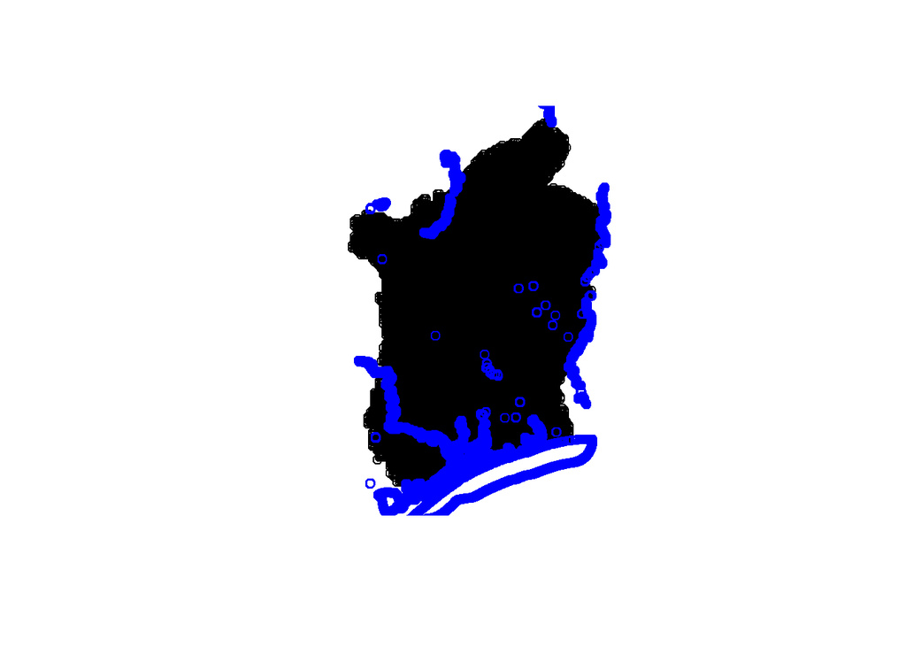

```r
# draw test plot of water point locations
plot(st_geometry(point_grid))
plot(st_geometry(water_points),col='blue',add=TRUE)
```

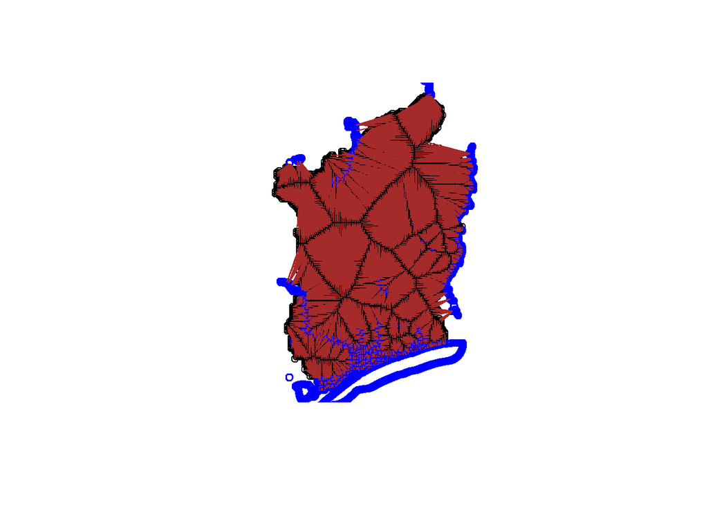

```r
# draw test plot with lines between demand points and nearest water point
plot(st_geometry(point_grid))
plot(st_geometry(water_points),col='blue',add=TRUE)
plot(st_geometry(near_lines),col="brown",add=TRUE)
```

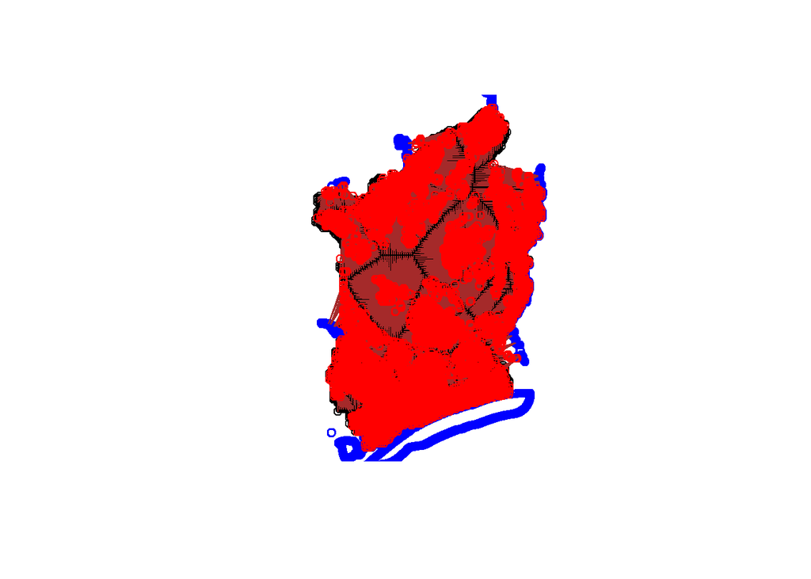

```r
# draw test plot including max DEM point in red
plot(st_geometry(point_grid))
plot(st_geometry(water_points),col='blue',add=TRUE)
plot(st_geometry(near_lines),add=TRUE,col='brown')
plot(st_geometry(max_dem_vertex),add=TRUE,col = 'red')
```

### Calculate helicopter travel times

- Calculate the distances between start to high dem point, and high dem point to end (water)
- Using distances, height differences and speeds (all_empty_kmh<-148,full_ascend_kmh<-74,full_level_kmh<-148) to calculate time on different segments of line. At the moment this assumes heli ascends and descends vertically (not on an angle)

```r
# get distance between high point and start and end points
high_point_to_wp<-st_distance(max_dem_vertex ,water_points)
near_lines$peak_to_wp<-as.numeric(apply(high_point_to_wp, 1, FUN=min))
near_lines$dist<-as.numeric(st_length(near_lines))
near_lines$peak_to_start<-near_lines$dist - near_lines$peak_to_wp

# calculate slope
near_lines$slp_wp_dist<-sqrt((near_lines$wp_peak_diff^2)+(near_lines$peak_to_wp^2))
near_lines$slp_start_dist<-sqrt((near_lines$st_peak_diff^2)+(near_lines$peak_to_start^2))

# calculate times
near_lines <- near_lines %>% mutate(time_full_ascend = (wp_peak_diff/1000)/full_ascend_kmh) %>%
  mutate(time_full_level = (dist/1000)/full_level_kmh) %>%
  mutate(time_full_descend = (st_peak_diff/1000)/full_level_kmh) %>%
  mutate(time_empty_ascend = (st_peak_diff/1000)/all_empty_kmh) %>%
  mutate(time_empty_level = (dist/1000)/all_empty_kmh) %>%
  mutate(time_empty_descend = (wp_peak_diff/1000)/all_empty_kmh) %>%
  mutate(total_time = round((time_full_ascend + time_full_level +time_full_descend +
           time_empty_ascend + time_empty_level + time_empty_descend)*60,1) + 2) #plus 2 minutes for fill time

point_grid$total_time<-near_lines$total_time

# calculate times using pythagoras (ie assuming heli flies on angles over)
near_lines <- near_lines %>% mutate(time_full_ascend_slope = (slp_wp_dist/1000)/full_ascend_kmh) %>%
  mutate(time_full_descend_slope = (slp_start_dist/1000)/full_level_kmh) %>%
  mutate(time_empty_ascend_slope = (slp_start_dist/1000)/all_empty_kmh) %>%
  mutate(time_empty_descend_slope = (slp_wp_dist/1000)/all_empty_kmh) %>%
  mutate(total_time_slope = round((time_full_ascend_slope +time_full_descend_slope +
           time_empty_ascend_slope + time_empty_descend_slope)*60,1) + 2) #plus 2 minutes for fill time

point_grid$total_time<-near_lines$total_time
point_grid$total_time_slope<-near_lines$total_time_slope

#st_write(point_grid, paste0(output_path, "point_grid.shp"), delete_layer = TRUE)
#st_write(near_lines, paste0(output_path, "near_lines.shp"), delete_layer = TRUE)
#st_write(max_dem_vertice, paste0("D:/TEMP/", "max_dem.shp"), delete_layer = TRUE)
#MJ writes point_grid and near_lines layer at the end
```

### Helicopter travel time map (simple)

- Interactive map of time to closest reservoir (in minutes). Click on a point to see the minutes
- This map assumes helicopters ascend and descend vertically, and fly horizontally in-between

```r
# Generate travel time grid
point_grid_wgs<-st_transform(point_grid,4326) %>% filter(total_time > 0) %>% as("Spatial")

# Create a custom color palette from green (0) to red (30)
qpal <- colorNumeric(
  palette = c("green", "red"),
  domain = c(0, 20)
)

# Create a Leaflet map
map <- leaflet(point_grid_wgs) %>%
  addTiles() %>%
  setView(lng = 147.2, lat = -37.5, zoom = 8) %>%
  addCircleMarkers(
    color = ~qpal(total_time),
    popup = ~htmlEscape(total_time),
    radius = 3,
    fillOpacity = 0.5
  ) %>%
  addPolygons(data=as(st_transform(water_poly,4326),"Spatial"))%>%
  addLegend(
    "bottomright",
    pal = qpal, values = ~total_time,
    title = "time in minutes",
    opacity = 1
  )

# Create a JavaScript function to update circle size based on zoom
# NOTE: I can't make this work at the moment.
js_code <- "
function(e) {
  var zoom = e.target.getZoom();              // Get the current zoom level
  var newRadius = 8 / zoom;                   // Adjust the radius based on zoom level
  map.eachLayer(function(layer) {
    if (layer instanceof L.CircleMarker) {
      layer.setRadius(newRadius);             // Update the circle's radius
    }
  });
}
"

# Add an event listener to the map
map <- map %>%
  htmlwidgets::onRender(js_code)

# Add blue circles
#map <- map %>%
#  addCircleMarkers(
#    data = as(st_transform(water_poly, 4326), "Spatial"),
#    color = "blue",
#    radius = 1,
#    stroke = FALSE,
#    fillOpacity = 0.5
#  )

# Print the map
map
```

[interactive chart not shown]

### Helicopter travel time map (alternative)

```r
# Generate travel time grid
point_grid_wgs<-st_transform(point_grid,4326) %>% filter(total_time_slope > 0) %>% as("Spatial")

# Create a custom color palette from green (0) to red (30)
qpal <- colorNumeric(
  palette = c("green", "red"),
  domain = c(0, 20)
)

# Create a Leaflet map
map <- leaflet(point_grid_wgs) %>%
  addTiles() %>%
  setView(lng = 147.2, lat = -37.5, zoom = 8) %>%
  addCircleMarkers(
    color = ~qpal(total_time),
    popup = ~htmlEscape(total_time),
    radius = 3,
    fillOpacity = 0.5
  ) %>%
  addPolygons(data=as(st_transform(water_poly,4326),"Spatial"))%>%
  addLegend(
    "bottomright",
    pal = qpal, values = ~total_time,
    title = "time in minutes",
    opacity = 1
  )

# Create a JavaScript function to update circle size based on zoom
# NOTE: I can't make this work at the moment.
js_code <- "
function(e) {
  var zoom = e.target.getZoom();              // Get the current zoom level
  var newRadius = 8 / zoom;                   // Adjust the radius based on zoom level
  map.eachLayer(function(layer) {
    if (layer instanceof L.CircleMarker) {
      layer.setRadius(newRadius);             // Update the circle's radius
    }
  });
}
"

# Add an event listener to the map
map <- map %>%
  htmlwidgets::onRender(js_code)

# Add blue circles
#map <- map %>%
#  addCircleMarkers(
#    data = as(st_transform(water_poly, 4326), "Spatial"),
#    color = "blue",
#    radius = 1,
#    stroke = FALSE,
#    fillOpacity = 0.5
#  )

# Print the map
map
```

[interactive chart not shown]

### Export final data to ArcGIS

- To do

```r
# To do
st_write(point_grid, paste0(output_path, "point_grid.shp"), delete_layer = TRUE)
```

```
## Deleting layer `outputspoint_grid' using driver `ESRI Shapefile'
## Writing layer `outputspoint_grid' to data source
##   `C:/Projects/20230829_HeliWaterPoints/waterpoints/outputspoint_grid.shp' using driver `ESRI Shapefile'
## Writing 12027 features with 32 fields and geometry type Point.
```

```r
st_write(near_lines, paste0(output_path, "near_lines.shp"), delete_layer = TRUE)
```

```
## Deleting layer `outputsnear_lines' using driver `ESRI Shapefile'
## Writing layer `outputsnear_lines' to data source
##   `C:/Projects/20230829_HeliWaterPoints/waterpoints/outputsnear_lines.shp' using driver `ESRI Shapefile'
## Writing 12027 features with 24 fields and geometry type Line String.
```